# Bellabeat Case Study

Samantha Schloeman

2024-11-27

## The Business Task

#### In this case study, we’re tasked with analyzing fitbit user data from the FitBit Fitness Tracker dataset found on Kaggle: https://www.kaggle.com/datasets/arashnic/fitbit (CC0: Public Domain, dataset made available through Mobius).

#### Our goal is to understand user behavior in order to supply the Bellabeat marketing team with a set of recommendations to grow one of the brand’s product offerings. In this case, I chose to focus on the brand’s wellness application, the Bellabeat App.

#### The questions underlying my analysis include:

-What trends exist in smart device usage?  
-How could these trends apply to Bellabeat customers?  
-How could these trends influence the Bellabeat marketing strategy?

## Download and Inspect the Data

#### Setting up the environment

```r
#Load libraries
library(readr)
library(janitor)
library(here)
library(skimr)
library(dplyr)
library(lubridate)
library(ggplot2)
library(tidyr)
library(Hmisc)

#read files
dailyactivity_merged_marapr <- read_csv("dailyActivity_merged.csv")
dailyactivity_merged_aprmay <- read_csv("dailyActivity_merged_AprMay.csv")
weightmarapr <- read_csv("weightLogInfo_merged_MarApr.csv")
weightaprmay <- read_csv("weightLogInfo_merged_AprMay.csv")
```

```r
#Review
head(dailyactivity_merged_marapr)
```

```
## # A tibble: 6 × 15
##           Id ActivityDate TotalSteps TotalDistance TrackerDistance
##        <dbl> <chr>             <dbl>         <dbl>           <dbl>
## 1 1503960366 3/25/2016         11004          7.11            7.11
## 2 1503960366 3/26/2016         17609         11.6            11.6
## 3 1503960366 3/27/2016         12736          8.53            8.53
## 4 1503960366 3/28/2016         13231          8.93            8.93
## 5 1503960366 3/29/2016         12041          7.85            7.85
## 6 1503960366 3/30/2016         10970          7.16            7.16
## # ℹ 10 more variables: LoggedActivitiesDistance <dbl>,
## #   VeryActiveDistance <dbl>, ModeratelyActiveDistance <dbl>,
## #   LightActiveDistance <dbl>, SedentaryActiveDistance <dbl>,
## #   VeryActiveMinutes <dbl>, FairlyActiveMinutes <dbl>,
## #   LightlyActiveMinutes <dbl>, SedentaryMinutes <dbl>, Calories <dbl>
```

```r
head(dailyactivity_merged_aprmay)
```

```
## # A tibble: 6 × 15
##           Id ActivityDate TotalSteps TotalDistance TrackerDistance
##        <dbl> <chr>             <dbl>         <dbl>           <dbl>
## 1 1503960366 4/12/2016         13162          8.5             8.5
## 2 1503960366 4/13/2016         10735          6.97            6.97
## 3 1503960366 4/14/2016         10460          6.74            6.74
## 4 1503960366 4/15/2016          9762          6.28            6.28
## 5 1503960366 4/16/2016         12669          8.16            8.16
## 6 1503960366 4/17/2016          9705          6.48            6.48
## # ℹ 10 more variables: LoggedActivitiesDistance <dbl>,
## #   VeryActiveDistance <dbl>, ModeratelyActiveDistance <dbl>,
## #   LightActiveDistance <dbl>, SedentaryActiveDistance <dbl>,
## #   VeryActiveMinutes <dbl>, FairlyActiveMinutes <dbl>,
## #   LightlyActiveMinutes <dbl>, SedentaryMinutes <dbl>, Calories <dbl>
```

```r
head(weightmarapr)
```

```
## # A tibble: 6 × 8
##           Id Date       WeightKg WeightPounds   Fat   BMI IsManualReport   LogId
##        <dbl> <chr>         <dbl>        <dbl> <dbl> <dbl> <lgl>            <dbl>
## 1 1503960366 4/5/2016 …     53.3         118.    22  23.0 TRUE           1.46e12
## 2 1927972279 4/10/2016…    130.          286.    NA  46.2 FALSE          1.46e12
## 3 2347167796 4/3/2016 …     63.4         140.    10  24.8 TRUE           1.46e12
## 4 2873212765 4/6/2016 …     56.7         125.    NA  21.5 TRUE           1.46e12
## 5 2873212765 4/7/2016 …     57.2         126.    NA  21.6 TRUE           1.46e12
## 6 2891001357 4/5/2016 …     88.4         195.    NA  25.0 TRUE           1.46e12
```

```r
head(weightaprmay)
```

```
## # A tibble: 6 × 8
##           Id Date       WeightKg WeightPounds   Fat   BMI IsManualReport   LogId
##        <dbl> <chr>         <dbl>        <dbl> <dbl> <dbl> <lgl>            <dbl>
## 1 1503960366 5/2/2016 …     52.6         116.    22  22.6 TRUE           1.46e12
## 2 1503960366 5/3/2016 …     52.6         116.    NA  22.6 TRUE           1.46e12
## 3 1927972279 4/13/2016…    134.          294.    NA  47.5 FALSE          1.46e12
## 4 2873212765 4/21/2016…     56.7         125.    NA  21.5 TRUE           1.46e12
## 5 2873212765 5/12/2016…     57.3         126.    NA  21.7 TRUE           1.46e12
## 6 4319703577 4/17/2016…     72.4         160.    25  27.5 TRUE           1.46e12
```

```r
skim_without_charts(dailyactivity_merged_marapr)
```

Data summary

| Name | dailyactivity_merged_mara… |
| --- | --- |
| Number of rows | 457 |
| Number of columns | 15 |
| _______________________ |  |
| Column type frequency: |  |
| character | 1 |
| numeric | 14 |
| ________________________ |  |
| Group variables | None |

**Variable type: character**

| skim_variable | n_missing | complete_rate | min | max | empty | n_unique | whitespace |
| --- | --- | --- | --- | --- | --- | --- | --- |
| ActivityDate | 0 | 1 | 8 | 9 | 0 | 32 | 0 |

**Variable type: numeric**

| skim_variable | n_missing | complete_rate | mean | sd | p0 | p25 | p50 | p75 | p100 |
| --- | --- | --- | --- | --- | --- | --- | --- | --- | --- |
| Id | 0 | 1 | 4.628595e+09 | 2.293781e+09 | 1503960366 | 2.347168e+09 | 4.057193e+09 | 6.391747e+09 | 8.877689e+09 |
| TotalSteps | 0 | 1 | 6.546560e+03 | 5.398490e+03 | 0 | 1.988000e+03 | 5.986000e+03 | 1.019800e+04 | 2.849700e+04 |
| TotalDistance | 0 | 1 | 4.660000e+00 | 4.080000e+00 | 0 | 1.410000e+00 | 4.090000e+00 | 7.160000e+00 | 2.753000e+01 |
| TrackerDistance | 0 | 1 | 4.610000e+00 | 4.070000e+00 | 0 | 1.280000e+00 | 4.090000e+00 | 7.110000e+00 | 2.753000e+01 |
| LoggedActivitiesDistance | 0 | 1 | 1.800000e-01 | 8.500000e-01 | 0 | 0.000000e+00 | 0.000000e+00 | 0.000000e+00 | 6.730000e+00 |
| VeryActiveDistance | 0 | 1 | 1.180000e+00 | 2.490000e+00 | 0 | 0.000000e+00 | 0.000000e+00 | 1.310000e+00 | 2.192000e+01 |
| ModeratelyActiveDistance | 0 | 1 | 4.800000e-01 | 8.300000e-01 | 0 | 0.000000e+00 | 2.000000e-02 | 6.700000e-01 | 6.400000e+00 |
| LightActiveDistance | 0 | 1 | 2.890000e+00 | 2.240000e+00 | 0 | 8.700000e-01 | 2.930000e+00 | 4.460000e+00 | 1.251000e+01 |
| SedentaryActiveDistance | 0 | 1 | 0.000000e+00 | 1.000000e-02 | 0 | 0.000000e+00 | 0.000000e+00 | 0.000000e+00 | 1.000000e-01 |
| VeryActiveMinutes | 0 | 1 | 1.662000e+01 | 2.892000e+01 | 0 | 0.000000e+00 | 0.000000e+00 | 2.500000e+01 | 2.020000e+02 |
| FairlyActiveMinutes | 0 | 1 | 1.307000e+01 | 3.621000e+01 | 0 | 0.000000e+00 | 1.000000e+00 | 1.600000e+01 | 6.600000e+02 |
| LightlyActiveMinutes | 0 | 1 | 1.700700e+02 | 1.222100e+02 | 0 | 6.400000e+01 | 1.810000e+02 | 2.570000e+02 | 7.200000e+02 |
| SedentaryMinutes | 0 | 1 | 9.952800e+02 | 3.370200e+02 | 32 | 7.280000e+02 | 1.057000e+03 | 1.285000e+03 | 1.440000e+03 |
| Calories | 0 | 1 | 2.189450e+03 | 8.154800e+02 | 0 | 1.776000e+03 | 2.062000e+03 | 2.667000e+03 | 4.562000e+03 |

```r
skim_without_charts(dailyactivity_merged_aprmay)
```

Data summary

| Name | dailyactivity_merged_aprm… |
| --- | --- |
| Number of rows | 940 |
| Number of columns | 15 |
| _______________________ |  |
| Column type frequency: |  |
| character | 1 |
| numeric | 14 |
| ________________________ |  |
| Group variables | None |

**Variable type: character**

| skim_variable | n_missing | complete_rate | min | max | empty | n_unique | whitespace |
| --- | --- | --- | --- | --- | --- | --- | --- |
| ActivityDate | 0 | 1 | 8 | 9 | 0 | 31 | 0 |

**Variable type: numeric**

| skim_variable | n_missing | complete_rate | mean | sd | p0 | p25 | p50 | p75 | p100 |
| --- | --- | --- | --- | --- | --- | --- | --- | --- | --- |
| Id | 0 | 1 | 4.855407e+09 | 2.424805e+09 | 1503960366 | 2.320127e+09 | 4.445115e+09 | 6.962181e+09 | 8.877689e+09 |
| TotalSteps | 0 | 1 | 7.637910e+03 | 5.087150e+03 | 0 | 3.789750e+03 | 7.405500e+03 | 1.072700e+04 | 3.601900e+04 |
| TotalDistance | 0 | 1 | 5.490000e+00 | 3.920000e+00 | 0 | 2.620000e+00 | 5.240000e+00 | 7.710000e+00 | 2.803000e+01 |
| TrackerDistance | 0 | 1 | 5.480000e+00 | 3.910000e+00 | 0 | 2.620000e+00 | 5.240000e+00 | 7.710000e+00 | 2.803000e+01 |
| LoggedActivitiesDistance | 0 | 1 | 1.100000e-01 | 6.200000e-01 | 0 | 0.000000e+00 | 0.000000e+00 | 0.000000e+00 | 4.940000e+00 |
| VeryActiveDistance | 0 | 1 | 1.500000e+00 | 2.660000e+00 | 0 | 0.000000e+00 | 2.100000e-01 | 2.050000e+00 | 2.192000e+01 |
| ModeratelyActiveDistance | 0 | 1 | 5.700000e-01 | 8.800000e-01 | 0 | 0.000000e+00 | 2.400000e-01 | 8.000000e-01 | 6.480000e+00 |
| LightActiveDistance | 0 | 1 | 3.340000e+00 | 2.040000e+00 | 0 | 1.950000e+00 | 3.360000e+00 | 4.780000e+00 | 1.071000e+01 |
| SedentaryActiveDistance | 0 | 1 | 0.000000e+00 | 1.000000e-02 | 0 | 0.000000e+00 | 0.000000e+00 | 0.000000e+00 | 1.100000e-01 |
| VeryActiveMinutes | 0 | 1 | 2.116000e+01 | 3.284000e+01 | 0 | 0.000000e+00 | 4.000000e+00 | 3.200000e+01 | 2.100000e+02 |
| FairlyActiveMinutes | 0 | 1 | 1.356000e+01 | 1.999000e+01 | 0 | 0.000000e+00 | 6.000000e+00 | 1.900000e+01 | 1.430000e+02 |
| LightlyActiveMinutes | 0 | 1 | 1.928100e+02 | 1.091700e+02 | 0 | 1.270000e+02 | 1.990000e+02 | 2.640000e+02 | 5.180000e+02 |
| SedentaryMinutes | 0 | 1 | 9.912100e+02 | 3.012700e+02 | 0 | 7.297500e+02 | 1.057500e+03 | 1.229500e+03 | 1.440000e+03 |
| Calories | 0 | 1 | 2.303610e+03 | 7.181700e+02 | 0 | 1.828500e+03 | 2.134000e+03 | 2.793250e+03 | 4.900000e+03 |

```r
skim_without_charts(weightmarapr)
```

Data summary

| Name | weightmarapr |
| --- | --- |
| Number of rows | 33 |
| Number of columns | 8 |
| _______________________ |  |
| Column type frequency: |  |
| character | 1 |
| logical | 1 |
| numeric | 6 |
| ________________________ |  |
| Group variables | None |

**Variable type: character**

| skim_variable | n_missing | complete_rate | min | max | empty | n_unique | whitespace |
| --- | --- | --- | --- | --- | --- | --- | --- |
| Date | 0 | 1 | 19 | 21 | 0 | 24 | 0 |

**Variable type: logical**

| skim_variable | n_missing | complete_rate | mean | count |
| --- | --- | --- | --- | --- |
| IsManualReport | 0 | 1 | 0.7 | TRU: 23, FAL: 10 |

**Variable type: numeric**

| skim_variable | n_missing | complete_rate | mean | sd | p0 | p25 | p50 | p75 | p100 |
| --- | --- | --- | --- | --- | --- | --- | --- | --- | --- |
| Id | 0 | 1.00 | 6.477156e+09 | 2.308888e+09 | 1.503960e+09 | 4.702922e+09 | 6.962181e+09 | 8.877689e+09 | 8.877689e+09 |
| WeightKg | 0 | 1.00 | 7.344000e+01 | 1.653000e+01 | 5.330000e+01 | 6.170000e+01 | 6.250000e+01 | 8.580000e+01 | 1.296000e+02 |
| WeightPounds | 0 | 1.00 | 1.619100e+02 | 3.644000e+01 | 1.175100e+02 | 1.360300e+02 | 1.377900e+02 | 1.891600e+02 | 2.857200e+02 |
| Fat | 31 | 0.06 | 1.600000e+01 | 8.490000e+00 | 1.000000e+01 | 1.300000e+01 | 1.600000e+01 | 1.900000e+01 | 2.200000e+01 |
| BMI | 0 | 1.00 | 2.573000e+01 | 4.330000e+00 | 2.145000e+01 | 2.410000e+01 | 2.439000e+01 | 2.576000e+01 | 4.617000e+01 |
| LogId | 0 | 1.00 | 1.459959e+12 | 3.088072e+08 | 1.459382e+12 | 1.459753e+12 | 1.459987e+12 | 1.460160e+12 | 1.460506e+12 |

```r
skim_without_charts(weightaprmay)
```

Data summary

| Name | weightaprmay |
| --- | --- |
| Number of rows | 67 |
| Number of columns | 8 |
| _______________________ |  |
| Column type frequency: |  |
| character | 1 |
| logical | 1 |
| numeric | 6 |
| ________________________ |  |
| Group variables | None |

**Variable type: character**

| skim_variable | n_missing | complete_rate | min | max | empty | n_unique | whitespace |
| --- | --- | --- | --- | --- | --- | --- | --- |
| Date | 0 | 1 | 19 | 21 | 0 | 56 | 0 |

**Variable type: logical**

| skim_variable | n_missing | complete_rate | mean | count |
| --- | --- | --- | --- | --- |
| IsManualReport | 0 | 1 | 0.61 | TRU: 41, FAL: 26 |

**Variable type: numeric**

| skim_variable | n_missing | complete_rate | mean | sd | p0 | p25 | p50 | p75 | p100 |
| --- | --- | --- | --- | --- | --- | --- | --- | --- | --- |
| Id | 0 | 1.00 | 7.009282e+09 | 1.950322e+09 | 1.503960e+09 | 6.962181e+09 | 6.962181e+09 | 8.877689e+09 | 8.877689e+09 |
| WeightKg | 0 | 1.00 | 7.204000e+01 | 1.392000e+01 | 5.260000e+01 | 6.140000e+01 | 6.250000e+01 | 8.505000e+01 | 1.335000e+02 |
| WeightPounds | 0 | 1.00 | 1.588100e+02 | 3.070000e+01 | 1.159600e+02 | 1.353600e+02 | 1.377900e+02 | 1.875000e+02 | 2.943200e+02 |
| Fat | 65 | 0.03 | 2.350000e+01 | 2.120000e+00 | 2.200000e+01 | 2.275000e+01 | 2.350000e+01 | 2.425000e+01 | 2.500000e+01 |
| BMI | 0 | 1.00 | 2.519000e+01 | 3.070000e+00 | 2.145000e+01 | 2.396000e+01 | 2.439000e+01 | 2.556000e+01 | 4.754000e+01 |
| LogId | 0 | 1.00 | 1.461772e+12 | 7.829948e+08 | 1.460444e+12 | 1.461079e+12 | 1.461802e+12 | 1.462375e+12 | 1.463098e+12 |

#### The unique user Id column will be useful.

#### Synchronize the date variables. Remove duplicates, unwanted columns, and compare column names to merge the like dataframes.

```r
#Remove duplicates
dailyactivity_merged_marapr <- distinct(dailyactivity_merged_marapr)
dailyactivity_merged_aprmay <- distinct(dailyactivity_merged_aprmay)
weightmarapr <- distinct(weightmarapr)
weightaprmay <- distinct(weightaprmay)

#Remove unwanted columns
weightmarapr <- weightmarapr %>%
  select(-Fat, -BMI, -WeightKg)
weightaprmay <- weightaprmay %>%
  select(-Fat, -BMI, -WeightKg)

#Compare col names for the rbind
compare_df_cols_same(dailyactivity_merged_marapr, dailyactivity_merged_aprmay)
```

```
## [1] TRUE
```

```r
compare_df_cols_same(weightmarapr, weightaprmay)
```

```
## [1] TRUE
```

```r
#merge like dataframes
daily_activity <- rbind(dailyactivity_merged_marapr, dailyactivity_merged_aprmay)
daily_weight <- rbind(weightmarapr, weightaprmay)

#Convert character to date in the activity df
daily_activity <- daily_activity %>%
  mutate(ActivityDate = convert_to_date(ActivityDate,
                                        character_fun = lubridate::mdy))

#Isolate date from time in the weight df
daily_weight <- daily_weight %>%
  separate(Date, c("Day", NA), " ", remove = FALSE, extra = "merge") %>%
  mutate(Day = convert_to_date(Day,
                                character_fun = lubridate::mdy))
```

#### How many unique participants are in each df?

```r
n_distinct(daily_activity$Id)
```

```
## [1] 35
```

```r
n_distinct(daily_weight$Id)
```

```
## [1] 13
```

#### We’ll focus on sedentary minutes, very active minutes, calories, and weight in this analysis. More time spent sedentary is correlated with adverse health outcomes according to [the NIH.](https://pmc.ncbi.nlm.nih.gov/articles/PMC6527341/#:~:text=Results:,the%202018%20PAGAC%20Scientific%20Report.)

#### Summary statistics

```r
daily_activity %>%
  select(TotalSteps, TotalDistance, SedentaryMinutes) %>%
  summary()
```

```
##    TotalSteps    TotalDistance    SedentaryMinutes
##  Min.   :    0   Min.   : 0.000   Min.   :   0.0
##  1st Qu.: 3146   1st Qu.: 2.170   1st Qu.: 729.0
##  Median : 6999   Median : 4.950   Median :1057.0
##  Mean   : 7281   Mean   : 5.219   Mean   : 992.5
##  3rd Qu.:10544   3rd Qu.: 7.500   3rd Qu.:1244.0
##  Max.   :36019   Max.   :28.030   Max.   :1440.0
```

```r
daily_weight %>%
  select(WeightPounds, IsManualReport) %>%
  summary()
```

```
##   WeightPounds   IsManualReport
##  Min.   :116.0   Mode :logical
##  1st Qu.:135.6   FALSE:36
##  Median :137.8   TRUE :64
##  Mean   :159.8
##  3rd Qu.:188.1
##  Max.   :294.3
```

#### 75% of our participants log less than 11k steps per day and spend more than 729 minutes (>12 hours) sedentary. 75% are less than 188 lbs and 2/3 of the weight records are manually entered.

#### How do sedentary minutes change throughout the week?

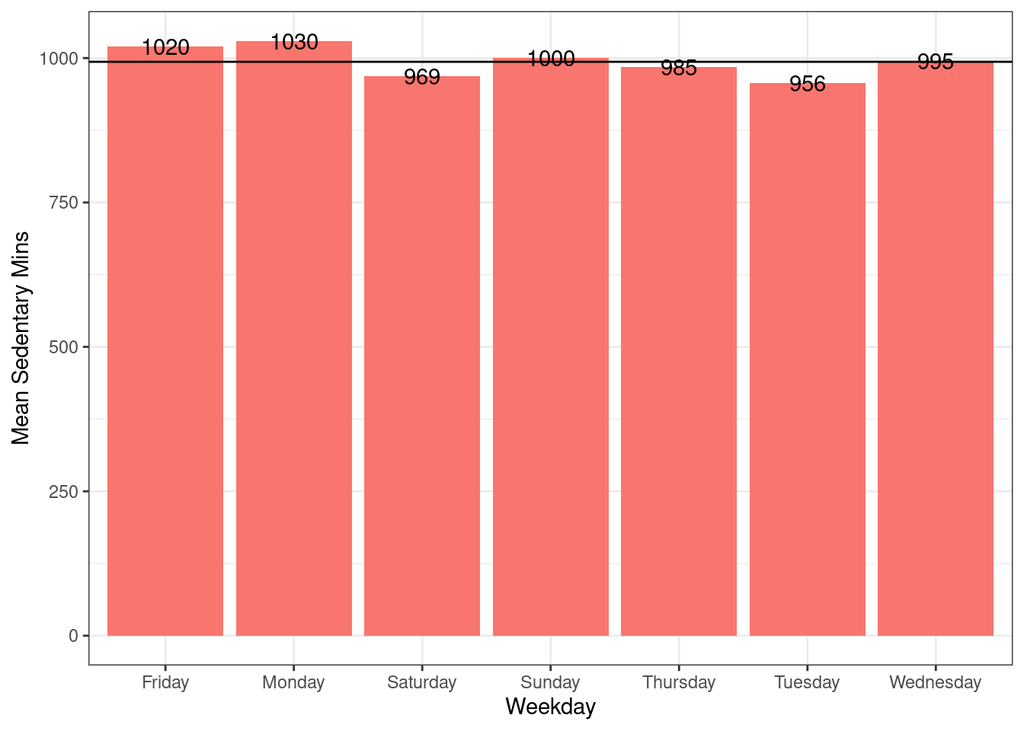

```r
daily_activity$Weekday <- daily_activity$ActivityDate %>% weekdays()

daily_activity %>%
  group_by(Weekday) %>%
  summarise(mean_sedentary_mins = mean(SedentaryMinutes)) %>%
  arrange(mean_sedentary_mins) %>%
  ggplot(aes(x=Weekday, y=mean_sedentary_mins, label=round(mean_sedentary_mins), fill = "ef8d76")) +
  geom_col() +
  geom_text(position = "identity") +
  geom_hline(aes(yintercept = mean(mean_sedentary_mins))) +
  labs(y="Mean Sedentary Mins") +
  theme_bw() +
  theme(legend.position = "none")
```

#### How does weight change through time?

[output not shown]

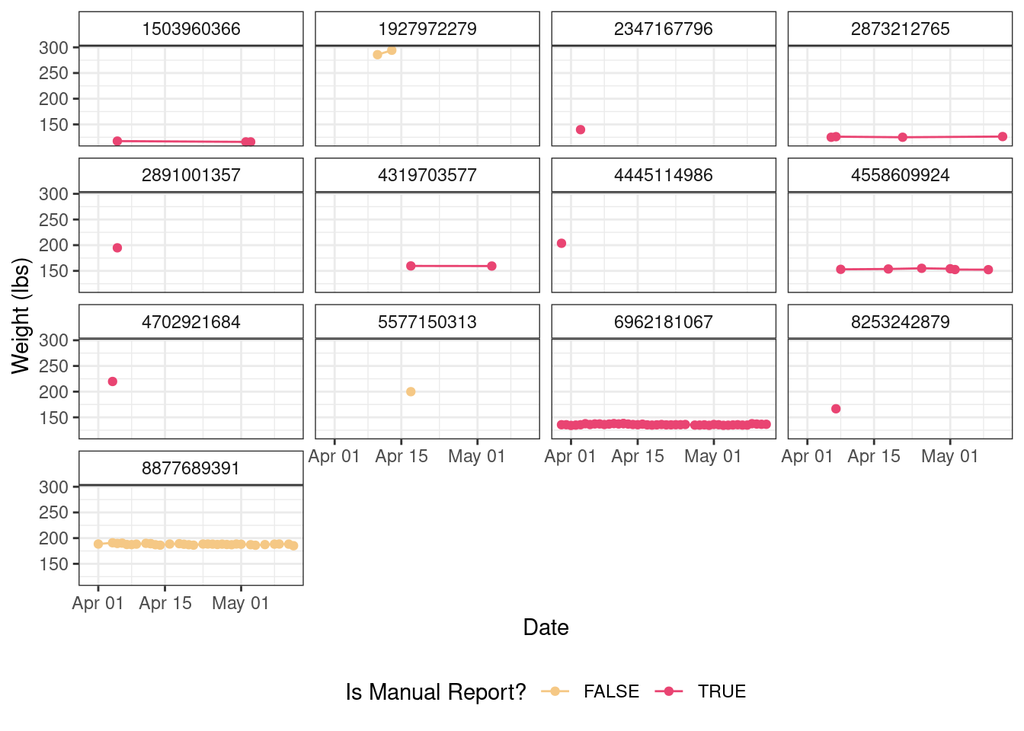

```r
daily_weight %>%
ggplot(aes(x=Day, y=WeightPounds, color=IsManualReport)) +
  geom_line() +
  geom_point() +
  facet_wrap(~Id) +
  labs(y="Weight (lbs)", x="Date", color="Is Manual Report?") +
  theme_bw() +
  theme(strip.background = element_rect("white"), legend.position = "bottom") +
  scale_color_manual(values=c("#f5c885", "#e94472"))
```

#### Only 2 out of 13 users are tracking their weight consistently.

#### What’s the relationship between total steps and calories?

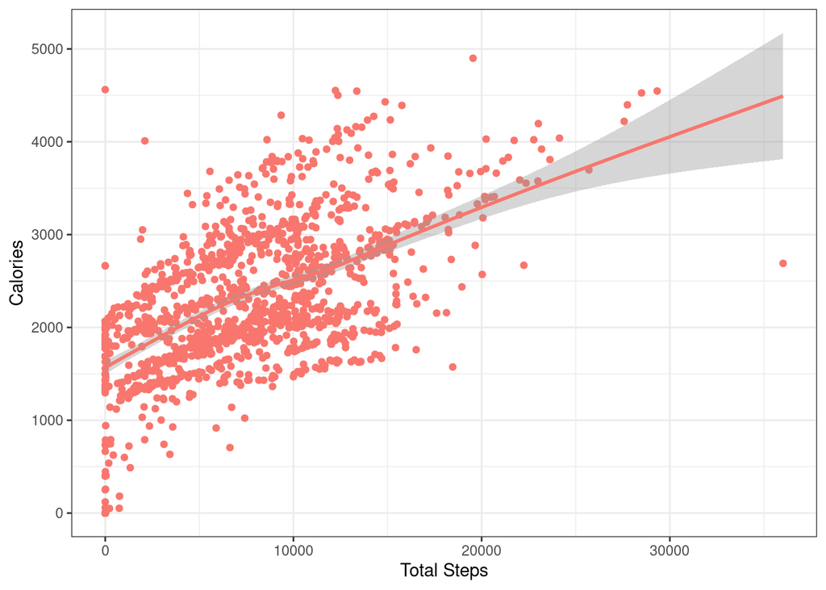

```r
ggplot(data = daily_activity, aes(x=TotalSteps, y=Calories, color="#e94472")) +
  geom_point() +
  geom_smooth() +
  labs(x="Total Steps") +
  theme_bw() +
  theme(legend.position = "none")
```

```r
cor(daily_activity$TotalSteps, daily_activity$Calories)
```

```
## [1] 0.5901599
```

#### How does logged distance differ from total distance?

```r
daily_activity$LoggedActivitiesDistance %>%
  summary()
```

```
##    Min. 1st Qu.  Median    Mean 3rd Qu.    Max.
##  0.0000  0.0000  0.0000  0.1315  0.0000  6.7271
```

```r
daily_activity$TotalDistance %>%
  summary()
```

```
##    Min. 1st Qu.  Median    Mean 3rd Qu.    Max.
##   0.000   2.170   4.950   5.219   7.500  28.030
```

```r
daily_activity$LoggedPercentage <- ((daily_activity$LoggedActivitiesDistance/daily_activity$TotalDistance)*100)
summary(daily_activity$LoggedPercentage)
```

```
##    Min. 1st Qu.  Median    Mean 3rd Qu.    Max.    NA's
##       0       0       0     Inf       0     Inf     140
```

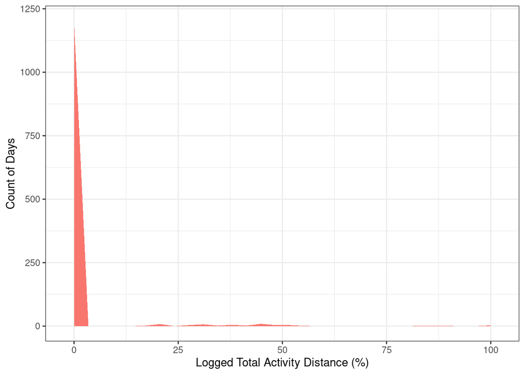

```r
daily_activity %>%
  na.omit() %>%
  ggplot(aes(x=LoggedPercentage, fill = "#f5c885")) +
  geom_area(stat="bin") +
  labs(x="Logged Total Activity Distance (%)", y="Count of Days") +
  theme_bw() +
  theme(legend.position = "none")
```

#### Do sedentary minutes change through time spent with the device?

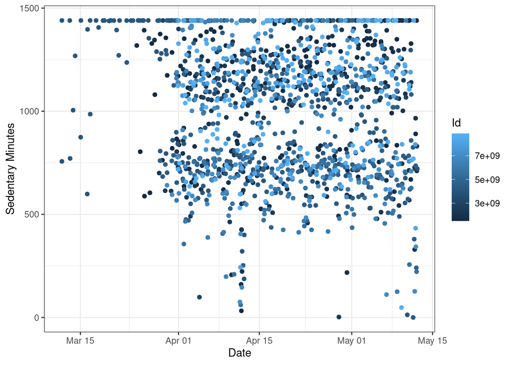

```r
daily_activity %>%
  select(Id, ActivityDate, SedentaryMinutes) %>%
  ggplot(aes(x=ActivityDate, y=SedentaryMinutes, color=Id)) +
  geom_point(position="jitter") +
  theme_bw() +
  labs(x="Date", y="Sedentary Minutes")
```

#### Let’s look at a small sample of users.

```r
sed_avg_wks1and2 <- daily_activity %>%
  filter(ActivityDate < "2016-03-26") %>%
  group_by(Id) %>%
  summarise(mean_sed_mins_first = mean(SedentaryMinutes))
sed_avg_wks1and2
```

```
## # A tibble: 4 × 2
##           Id mean_sed_mins_first
##        <dbl>               <dbl>
## 1 1503960366                804
## 2 1624580081               1319
## 3 4020332650               1179.
## 4 4057192912               1392.
```

```r
sed_avg_lastwk <- daily_activity %>%
  filter(ActivityDate < "2016-05-12") %>%
  group_by(Id) %>%
  summarise(mean_sed_mins_last = mean(SedentaryMinutes))
sed_avg_lastwk
```

```
## # A tibble: 35 × 2
##            Id mean_sed_mins_last
##         <dbl>              <dbl>
##  1 1503960366               821.
##  2 1624580081              1273.
##  3 1644430081              1130.
##  4 1844505072              1169.
##  5 1927972279              1222.
##  6 2022484408              1106.
##  7 2026352035               689.
##  8 2320127002              1238.
##  9 2347167796               686.
## 10 2873212765              1118.
## # ℹ 25 more rows
```

```r
sed_avg_wks1and2$Id %in% sed_avg_lastwk$Id #Our 4 participants are in the last week
```

```
## [1] TRUE TRUE TRUE TRUE
```

```r
sed_time_comp <- inner_join(sed_avg_wks1and2, sed_avg_lastwk, by="Id")
sed_time_comp %>%
  mutate(change = mean_sed_mins_last - mean_sed_mins_first)
```

```
## # A tibble: 4 × 4
##           Id mean_sed_mins_first mean_sed_mins_last change
##        <dbl>               <dbl>              <dbl>  <dbl>
## 1 1503960366                804                821.   17.2
## 2 1624580081               1319               1273.  -45.8
## 3 4020332650               1179.              1166.  -13.3
## 4 4057192912               1392.              1342.  -49.7
```

#### How do sedentary minutes change with very active minutes?

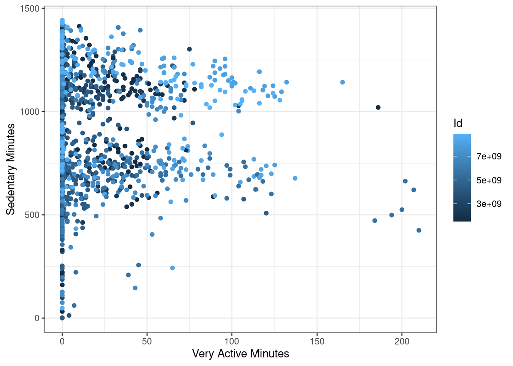

```r
ggplot(data=daily_activity, aes(x=VeryActiveMinutes, y=SedentaryMinutes, color=Id)) +
  geom_point() +
  theme_bw() +
  labs(x="Very Active Minutes", y="Sedentary Minutes")
```

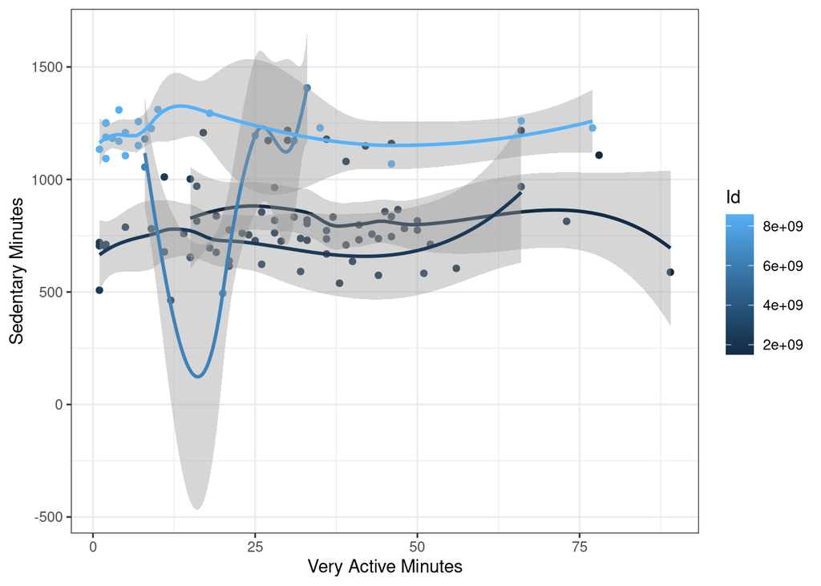

```r
#Take a sample of participants
user_sample <- sample(daily_activity$Id, 5)

daily_activity %>%
  filter(Id %in% user_sample) %>%
  filter(SedentaryMinutes > 0, VeryActiveMinutes > 0) %>%
  ggplot(aes(x=VeryActiveMinutes, y=SedentaryMinutes, group=Id, color=Id)) +
  geom_point() +
  geom_smooth() +
  theme_bw() +
  labs(x="Very Active Minutes", y="Sedentary Minutes")
```

```r
cor(daily_activity$VeryActiveMinutes, daily_activity$SedentaryMinutes)
```

```
## [1] -0.1678437
```